# 4sight signal analysis

## Summary

### Signal predictive power

#### Suggested actions:

Keep invest

- Ask what time can the signal for day t be send
- Ask the vendor for 2020 data to backtest again the simple strategy I designed
- If convincing, pursue the analysis as the signal shows strong predictive features
- Live trading with paper money for a month

#### Observations:

After this premilinary analysis, the signal shows strong predictive power. Indeed, a very basic trading strategy designed analysis pre 2018 data was able to generate strong performance.  
The analysis pre 2018 indicates statistical significance of the relashionship between the signal and the adjusted close daily moves. See below the trading strategy performance in 2019(similar results were obtained before that) and the signal feature S formula below:

[output not shown]

where $S_t = Log Return ( Signal_{t-3} + Signal_{t-6} )$  
we pay 1 basis point of transaction cost per buy/sell order.

### Data issues

#### Suggested actions:

- Notice the vendor of the Signal data issues and ask for root causes?: storage system or generating system?
- Negociate with the vendor about a course of action, compensation/penalty if their system fail to send a signal before a define hour of the day or send an absurd value

#### Observations:

Note that at the end of each issue we take the action specified in brackets

## Analysis

```python
import numpy as np
import pandas as pd
import matplotlib
import matplotlib.pyplot as plt
from datetime import datetime as dt
import pandas as pd
import statsmodels.api as sm
import seaborn as sns
from sklearn import linear_model
from scipy.stats import norm
from scipy.stats import pearsonr, kendalltau
from statsmodels.tsa.stattools import grangercausalitytests
import datetime as dt
import random
import locale
locale.setlocale( locale.LC_ALL, '' )
locale._override_localeconv = {'frac_digits':0}
plt.style.use('fivethirtyeight')
font = {'family' : 'normal',
        'weight' : 'bold',
        'size'   : 22}

matplotlib.rc('font', **font)
sns.set()
```

### Data Cleaning and Performance evaluation of the 4sight signal

The analysis is split in 3 sections:

| Section | Part |
| --- | --- |
| 1 | Data Cleaning |
| 2 | Signal Analysis |
| 3 | Trading Strategy |

At the end of each section in this notebook, we have a summary of the actions taken.

```python
path = 'C:/Users/owner/Documents/Python/millenium data cleaning/'
file_name = 'Sample Dataset.xlsx'
xl_file = pd.ExcelFile(path + file_name)
df = pd.read_excel(xl_file, 'Sheet1',parse_dates = ['Date'], index_col = 'Date')
```

```python
print(df.head())
```

```
               Signal        Open        High         Low       Close  \
Date
2015-11-19  13.768540  116.440002  116.650002  115.739998  116.059998
2015-11-20  13.608819  116.480003  117.360001  116.379997  116.809998
2015-11-23  12.990589  116.709999  117.889999  116.680000  117.389999
2015-11-24  12.667435  116.879997  118.419998  116.559998  118.250000
2015-11-25  13.019910  118.300003  119.320000  118.110001  119.169998

             Adj Close
Date
2015-11-19  108.281601
2015-11-20  108.981323
2015-11-23  109.522453
2015-11-24  110.324837
2015-11-25  111.183159
```

```python
print(df.tail())
```

```
            Signal        Open        High         Low       Close   Adj Close
Date
2019-12-30     0.0  165.979996  166.210007  164.570007  165.440002  163.623688
2019-12-31     0.0  165.080002  166.350006  164.710007  165.669998  163.851135
2020-01-02     0.0  166.740005  166.750000  164.229996  165.779999  163.959946
2020-01-03     0.0  163.740005  165.410004  163.699997  165.130005  163.317093
2020-01-06     0.0  163.850006  165.539993  163.539993  165.350006  163.534668
```

```python
print(df.index.min())
print(df.index.max())
print(df.shape)
```

```
2015-11-19 00:00:00
2020-01-06 00:00:00
(1038, 6)
```

## 1 Data Cleaning

### 1.1 Date investigation

We investigate the days for which we have data. ETF are traded on exchange so we try to match our dates with an exchange calendar.

```python
sorted(df.index.to_series().diff(),reverse = True)
```

```
[NaT,
 Timedelta('10 days 00:00:00'),
 Timedelta('4 days 00:00:00'),
 Timedelta('4 days 00:00:00'),
 Timedelta('4 days 00:00:00'),
 Timedelta('4 days 00:00:00'),
 Timedelta('4 days 00:00:00'),
 Timedelta('4 days 00:00:00'),
 Timedelta('4 days 00:00:00'),
 Timedelta('4 days 00:00:00'),
 Timedelta('4 days 00:00:00'),
 Timedelta('4 days 00:00:00'),
 Timedelta('4 days 00:00:00'),
 Timedelta('4 days 00:00:00'),
 Timedelta('4 days 00:00:00'),
 Timedelta('4 days 00:00:00'),
 Timedelta('4 days 00:00:00'),
 Timedelta('4 days 00:00:00'),
 Timedelta('4 days 00:00:00'),
 Timedelta('4 days 00:00:00'),
 Timedelta('4 days 00:00:00'),
 Timedelta('4 days 00:00:00'),
 Timedelta('4 days 00:00:00'),
 Timedelta('4 days 00:00:00'),
 Timedelta('4 days 00:00:00'),
 Timedelta('4 days 00:00:00'),
 Timedelta('4 days 00:00:00'),
 Timedelta('4 days 00:00:00'),
 Timedelta('4 days 00:00:00'),
 Timedelta('3 days 00:00:00'),
 Timedelta('3 days 00:00:00'),
 Timedelta('3 days 00:00:00'),
 Timedelta('3 days 00:00:00'),
 Timedelta('3 days 00:00:00'),
 Timedelta('3 days 00:00:00'),
 Timedelta('3 days 00:00:00'),
 Timedelta('3 days 00:00:00'),
 Timedelta('3 days 00:00:00'),
 Timedelta('3 days 00:00:00'),
 Timedelta('3 days 00:00:00'),
```

[output cut: 946 more lines]

```
 Timedelta('1 days 00:00:00'),
 Timedelta('1 days 00:00:00'),
 Timedelta('1 days 00:00:00'),
 Timedelta('1 days 00:00:00'),
 Timedelta('1 days 00:00:00'),
 Timedelta('1 days 00:00:00'),
 Timedelta('1 days 00:00:00'),
 Timedelta('1 days 00:00:00'),
 Timedelta('1 days 00:00:00'),
 Timedelta('1 days 00:00:00'),
 Timedelta('1 days 00:00:00'),
 Timedelta('1 days 00:00:00'),
 Timedelta('1 days 00:00:00'),
 Timedelta('1 days 00:00:00'),
 ...]
```

```python
sorted(df.index.to_series().diff(),reverse = True)
ts = df.index.to_series()
time_gaps = list(ts[ts-ts.shift()>dt.timedelta(days=4)])
time_gaps
```

```
[Timestamp('2018-11-19 00:00:00')]
```

```python
gap_period = ['2018-11-09','2018-11-19']
gap10 = ts[ts-ts.shift()==dt.timedelta(days=10)].iloc[0]
df[df.index <= gap10].tail()
```

| Date | Signal | Open | High | Low | Close | Adj Close |
| --- | --- | --- | --- | --- | --- | --- |
| 2018-11-06 | 17.968850 | 153.649994 | 155.110001 | 153.520004 | 154.639999 | 150.410355 |
| 2018-11-07 | 17.434010 | 155.360001 | 157.410004 | 154.800003 | 157.410004 | 153.104630 |
| 2018-11-08 | 17.835205 | 156.610001 | 157.899994 | 156.339996 | 156.990005 | 152.696091 |
| 2018-11-09 | 19.074848 | 156.000000 | 156.029999 | 152.949997 | 154.080002 | 149.865677 |
| 2018-11-19 | 17.769120 | 151.679993 | 152.029999 | 148.369995 | 148.860001 | 144.788452 |

```python
import pandas_market_calendars as mcal

# Create a calendar
nyse = mcal.get_calendar('NYSE')
dstr = lambda x: x.strftime('%Y-%m-%d')
early = nyse.schedule(start_date=dstr(df.index.min()), end_date=dstr(df.index.max()))
mkt_dt = mcal.date_range(early, frequency='1D').strftime("%Y-%m-%d")

data_dt = df.index.strftime("%Y-%m-%d")
# print(mcal.get_calendar_names())
print(len(set(mkt_dt) & set(data_dt)))
print(sorted(set(mkt_dt) - set(data_dt)))
```

```
1033
['2018-11-12', '2018-11-13', '2018-11-14', '2018-11-15', '2018-11-16']
```

```python
out_of_mkt = (sorted(set(data_dt) - set(mkt_dt)))
df[ [d in out_of_mkt for d in df.index.strftime("%Y-%m-%d")]]
```

| Date | Signal | Open | High | Low | Close | Adj Close |
| --- | --- | --- | --- | --- | --- | --- |
| 2017-07-04 | 15.282748 | 141.339996 | 142.600000 | 141.400003 | 142.200006 | 135.700998 |
| 2018-05-19 | 20.448445 | 162.369995 | 163.240005 | 162.360001 | 162.940002 | 157.493622 |
| 2018-05-20 | 19.483907 | 163.259995 | 163.330002 | 161.630005 | 161.759995 | 156.352997 |
| 2018-06-23 | 18.995502 | 167.240005 | 167.369995 | 164.139999 | 165.080002 | 159.562042 |
| 2018-06-24 | 20.274163 | 165.229996 | 166.660004 | 164.850006 | 166.039993 | 160.489944 |

```python
set([d.weekday()  for d in df.index.to_series()])
```

```
{0, 1, 2, 3, 4, 5, 6}
```

```python
wd = np.array([d.weekday()  for d in df.index.to_series()])
df.loc[wd>=5]
```

| Date | Signal | Open | High | Low | Close | Adj Close |
| --- | --- | --- | --- | --- | --- | --- |
| 2018-05-19 | 20.448445 | 162.369995 | 163.240005 | 162.360001 | 162.940002 | 157.493622 |
| 2018-05-20 | 19.483907 | 163.259995 | 163.330002 | 161.630005 | 161.759995 | 156.352997 |
| 2018-06-23 | 18.995502 | 167.240005 | 167.369995 | 164.139999 | 165.080002 | 159.562042 |
| 2018-06-24 | 20.274163 | 165.229996 | 166.660004 | 164.850006 | 166.039993 | 160.489944 |

Better safe than sorry, we delete this weekend data as well as the 2017-07-04 Labor Day. While currencies, crypto and other securites trade on weekend, it is very unlikely that a security only trade on 2 weekends.

```python
df.drop(df.index[ [d in out_of_mkt for d in df.index.strftime("%Y-%m-%d")]],inplace= True)
```

#### 1.2 Prices quality check

#### 1.2.1 Close and Adjusted Close prices relashionship

Adjusted close and close time series have 4 obvious incorrect observations. At any date, at least one serie seems to have a correct observation so we can use one to fix the other.

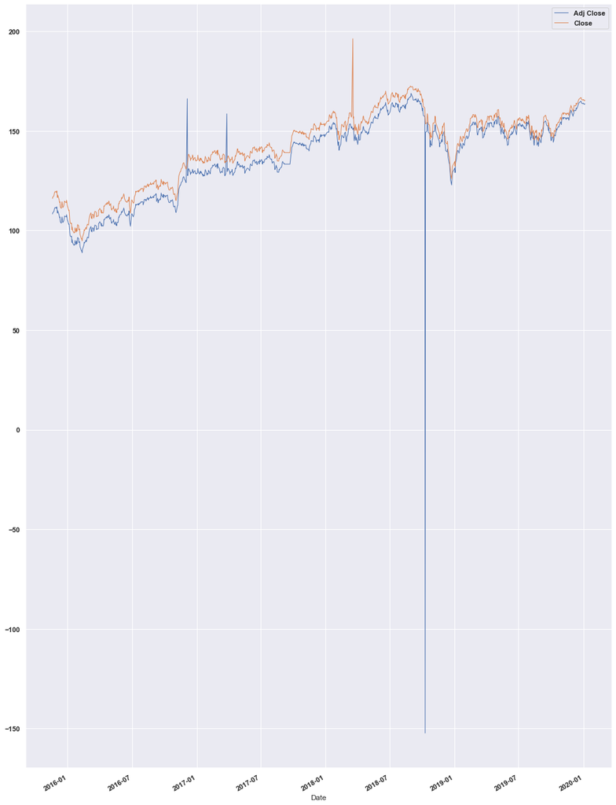

```python
df[['Adj Close', 'Close']].plot(figsize = (15, 25),linewidth=1)
```

Adjusted close and close time series have a piecewise linearly relastionship breaking at dividend dates. When we encounter an outlier in one series, we:

- Compute the local linear relashionship using the previous observation
- Input the correct value

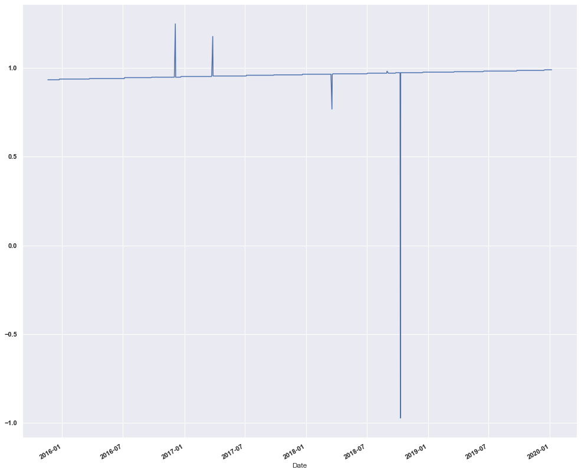

```python
(df['Adj Close']/df['Close']).plot(figsize = (15, 15))
```

A move of the close price greater than 20 points in classified as an outlier and corrected

```python
# We use the reference time series to correct the series error values

def fixClose(series, ref, max_move = 20):
    abs_moves = (df[series].diff(periods=1)[1:]).abs()
    # for one anomaly we observe two consecutives abnormal moves. The anomaly is at the first date
    anom_dates = abs_moves[abs_moves>=max_move].index

    df.loc[anom_dates[::2],series] = df.loc[anom_dates[::2],ref] * np.array(df.loc[anom_dates[1::2],series]/df.loc[anom_dates[1::2],ref])
    print(anom_dates[::2])

fixClose('Adj Close','Close')
fixClose('Close','Adj Close')
```

```
DatetimeIndex(['2016-12-05', '2017-03-27', '2018-10-10'], dtype='datetime64[ns]', name='Date', freq=None)
DatetimeIndex(['2018-03-19'], dtype='datetime64[ns]', name='Date', freq=None)
```

Two values still break the piecewise linear relationship. Only the second spike is large enough to be treated:

- we have a good confidence in our assessment of wether Close or Adj close was incorrect.
- leaving the incorrect data untreated would lead a large incorrect profit on this day

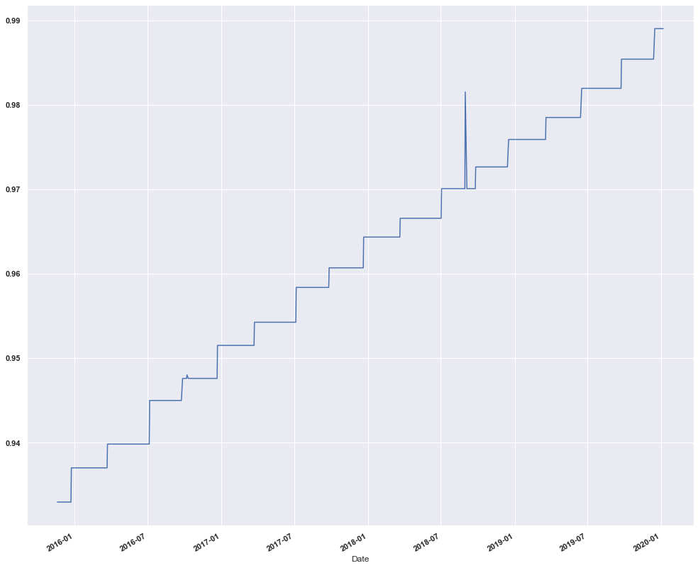

```python
(df['Adj Close']/df['Close']).plot(figsize = (15, 15))
```

We find the spike (2018-08-31) and correct it manually this time

```python
mask = (df.index >= '2018-08-30') & (df.index <= '2018-9-4')
df['Adj/Close'] = df['Adj Close']/df['Close']
df.loc[mask]
```

| Date | Signal | Open | High | Low | Close | Adj Close | Adj/Close |
| --- | --- | --- | --- | --- | --- | --- | --- |
| 2018-08-30 | 20.870663 | 172.169998 | 173.229996 | 171.820007 | 172.360001 | 167.202026 | 0.970074 |
| 2018-08-31 | 20.705795 | 171.960007 | 173.389999 | 171.949997 | 172.020004 | 168.842270 | 0.981527 |
| 2018-09-04 | 20.457543 | 172.789993 | 173.119995 | 171.119995 | 172.250000 | 167.095306 | 0.970074 |

on day 2018-08-31 the unadjusted Adj Close price is not in the High - Low range. We assume Close contains the correct value

```python
168.842270/0.970074
```

```
174.0509177650365
```

```python
df.loc[df.index == '2018-08-31','Adj Close'] = df.loc[df.index == '2018-08-31','Close'] * np.array(df.loc[df.index == '2018-08-30','Adj Close'] / df.loc[df.index == '2018-08-30','Close'])
```

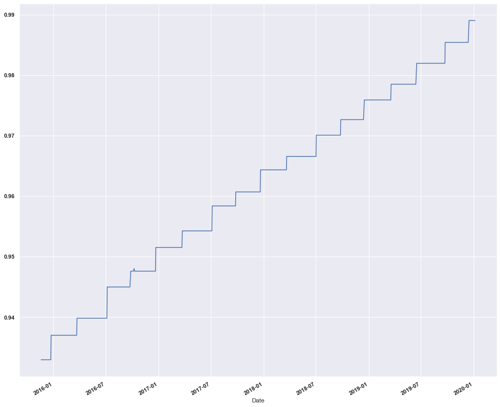

```python
(df['Adj Close']/df['Close']).plot(figsize = (15, 15))
```

#### 1.2.1 High and Low prices properties

Data cleaning based on the properties:

- Low <= Open <= High
- Low <= Close <= High

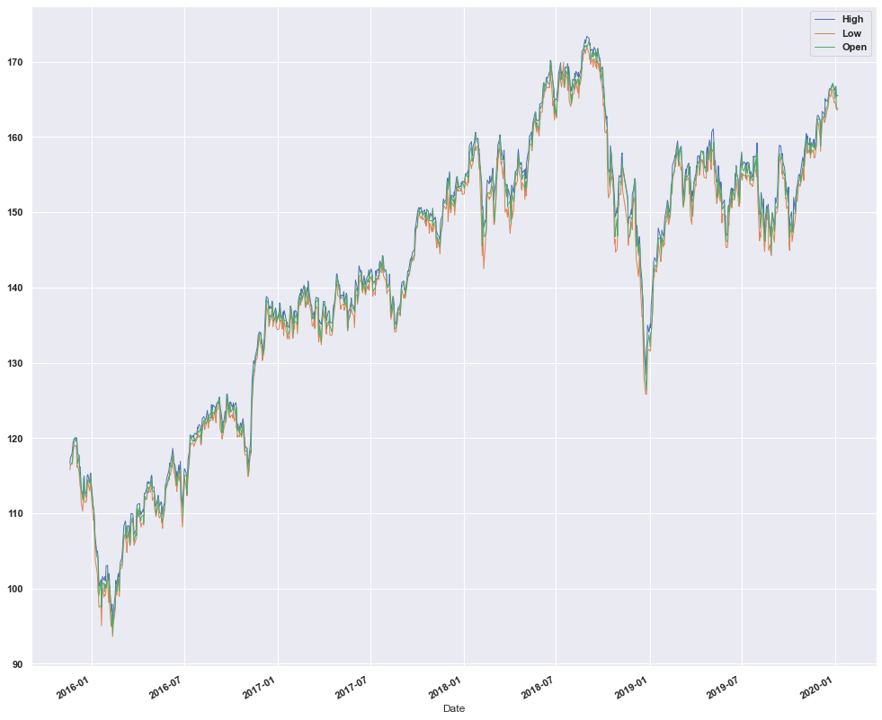

```python
df[['High', 'Low','Open']].plot(figsize = (15, 15),linewidth=1)
```

```python
mask_hl = ~( df['Low'] <= df['High'])
df.loc[mask_hl]
```

| Date | Signal | Open | High | Low | Close | Adj Close | Adj/Close |
| --- | --- | --- | --- | --- | --- | --- | --- |
| 2018-03-07 | 18.885411 | 154.460007 | 156.929993 | 157.220001 | 156.740005 | 151.151840 | 0.964348 |
| 2018-07-16 | 20.010313 | 167.759995 | 168.029999 | 169.960007 | 166.770004 | 161.779312 | 0.970074 |

```python
df.loc['2018-03-07','Low'] = df.loc['2018-03-07','Open']
df.loc['2018-07-16','Low'] = df.loc['2018-07-16','Close']
```

```python
mask_h = ~((df['Close'] <= df['High']) & (df['Open'] <= df['High']))

df.loc[mask_h]
# ind_h = [i for i, x in enumerate(mask_h) if x]
# indn_h = sorted([i-1 for i in ind_h] + ind_h + [i+1 for i in ind_h])
# mask_n_h = df.iloc[indn_h].index
# df.loc[mask_n_h]
```

| Date | Signal | Open | High | Low | Close | Adj Close | Adj/Close |
| --- | --- | --- | --- | --- | --- | --- | --- |
| 2017-08-07 | 16.298805 | 140.440002 | 140.350000 | 139.710007 | 140.440002 | 134.595871 | 0.958387 |
| 2018-12-06 | 16.904044 | 145.449997 | 147.099997 | 143.429993 | 147.199997 | 143.173874 | 0.972649 |
| 2019-10-17 | 18.878412 | 152.289993 | 153.309995 | 152.050003 | 153.339996 | 151.102173 | 0.985406 |

```python
df.loc[mask_h,'High'] = df.loc[mask_h,['High','Close','Open']].max(axis = 1)
```

```python
mask_l = ~((df['Close'] >= df['Low']) & (df['Open'] >= df['Low']))

df[mask_l]
```

| Date | Signal | Open | High | Low | Close | Adj Close | Adj/Close |
| --- | --- | --- | --- | --- | --- | --- | --- |
| 2017-09-11 | 15.838558 | 140.389999 | 140.919998 | 140.229996 | 139.110001 | 133.321198 | 0.958387 |
| 2017-09-12 | 15.518587 | 141.039993 | 141.690002 | 140.820007 | 139.110001 | 133.321198 | 0.958387 |
| 2017-09-13 | 16.158529 | 141.410004 | 142.220001 | 141.320007 | 139.110001 | 133.321198 | 0.958387 |
| 2017-09-14 | 16.478500 | 141.779999 | 142.160004 | 141.419998 | 139.110001 | 133.321198 | 0.958387 |
| 2017-09-15 | 15.198617 | 141.639999 | 142.470001 | 141.550003 | 139.110001 | 133.321198 | 0.958387 |
| 2017-09-18 | 15.518587 | 142.619995 | 143.809998 | 142.600006 | 139.110001 | 133.321198 | 0.958387 |
| 2017-09-19 | 16.798471 | 143.570007 | 143.690002 | 143.089996 | 139.110001 | 133.321198 | 0.958387 |
| 2017-09-20 | 15.953688 | 143.529999 | 144.020004 | 143.259995 | 139.110001 | 133.321198 | 0.958387 |
| 2017-09-21 | 16.004491 | 144.020004 | 144.259995 | 143.479996 | 139.110001 | 133.321198 | 0.958387 |
| 2017-09-22 | 16.997600 | 143.669998 | 144.669998 | 143.559998 | 139.110001 | 133.321198 | 0.958387 |
| 2018-10-19 | 17.461385 | 155.470001 | 156.360001 | 154.740005 | 153.360001 | 149.165390 | 0.972649 |
| 2019-06-10 | 19.055083 | 151.449997 | 153.139999 | 152.449997 | 151.750000 | 148.488159 | 0.978505 |
| 2019-09-24 | 18.630976 | 155.149994 | 155.289993 | 152.839996 | 152.429993 | 150.205444 | 0.985406 |

There is 2 weeks of wrong(constant) close and Adjusted close prices so we discard these days from the data. We can later make sure to split the data accordingly to avoid any time gap

Note: We could use the next day Open to replace the incorrect Close.

```python
incorrect_period = ['2017-09-11','2017-09-22']
mask = df.loc[(incorrect_period[0]<=df.index) & (df.index<=incorrect_period[1])].index
df.drop(mask,inplace = True)
```

```python
mask_l = ~((df['Close'] >= df['Low']) & (df['Open'] >= df['Low']))
df[mask_l]
```

| Date | Signal | Open | High | Low | Close | Adj Close | Adj/Close |
| --- | --- | --- | --- | --- | --- | --- | --- |
| 2018-10-19 | 17.461385 | 155.470001 | 156.360001 | 154.740005 | 153.360001 | 149.165390 | 0.972649 |
| 2019-06-10 | 19.055083 | 151.449997 | 153.139999 | 152.449997 | 151.750000 | 148.488159 | 0.978505 |
| 2019-09-24 | 18.630976 | 155.149994 | 155.289993 | 152.839996 | 152.429993 | 150.205444 | 0.985406 |

```python
df.loc[mask_l,'Low'] = df.loc[mask_l,['Low','Close','Open']].min(axis = 1)
```

#### 1.3 Signal quality check

The Signal has 5 visible incorrect values.

Since there are few isolated incorrect values, we use Last Observation Carried Forward for the signal incorrect values for the analysis. We do not want to discard the observations as it could disturb the eventual lag structure. We also remove the 0s value at the end of the data

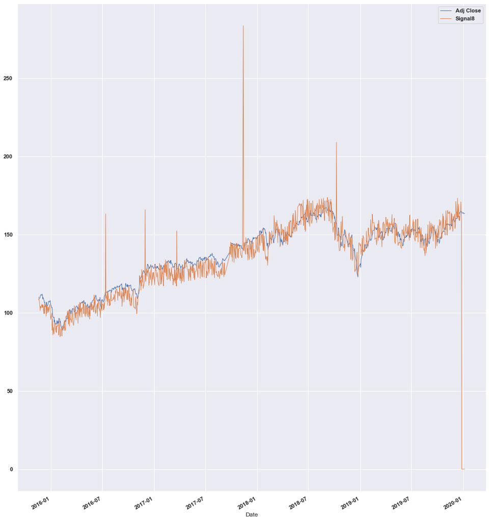

```python
df['Signal8'] =  8*df['Signal']
df[['Adj Close','Signal8']].plot(figsize = (15, 20),linewidth=1)
del df['Signal8']
```

```python
# pd.set_option('display.max_rows', None)
pd.set_option('display.max_rows', 20)

abs_moves = (8*df[ 'Signal'].diff(periods=1)).abs()
abs_moves.sort_values(ascending  = False)[:16]
```

```
Date
2019-12-27    160.133147
2017-11-14    143.822620
2017-11-13    142.446108
2016-07-14     53.848914
2016-07-13     52.396476
2018-10-10     51.243165
2018-10-09     46.057132
2016-12-01     43.471127
2016-11-30     43.255542
2017-03-22     35.189318
2017-03-23     26.594147
2018-07-06     16.196647
2018-06-14     16.143792
2018-10-08     16.107646
2018-07-02     15.471150
2018-12-04     15.436661
Name: Signal, dtype: float64
```

Apply LOCF to incorrect signals

```python
sgl = 'Signal'
df.drop(df[df[sgl] == 0].index, inplace = True)

max_move = 20
abs_moves = (df[sgl].diff()).abs()
# for one anomaly we observe two consecutives abnormal moves. The incorrect signal is at the first date
anom_moves_i = [i for i, x in enumerate(8*abs_moves>=max_move) if x]
anom_i = anom_moves_i[::2]
anom_dates = df.iloc[anom_i].index

df['Signal.L1'] = df['Signal'].shift()
print(8* df.loc[anom_dates,['Signal','Signal.L1']] )
# Last Observation Carried Forward
df.loc[anom_dates,sgl] = df.loc[anom_dates,'Signal.L1']
df.drop('Signal.L1', axis =1, inplace = True)
```

```
                Signal   Signal.L1
Date
2016-07-13  163.160662  110.764186
2016-11-30  165.909199  122.653657
2017-03-22  152.234532  117.045214
2017-11-13  283.473176  141.027068
2018-10-09  208.998983  162.941851
```

### 2. Signal Analysis

#### 2.1 Signal and Adjusted close feature engineering

In the graph we clearly observe a lag between the signal and the adjusted close prices.

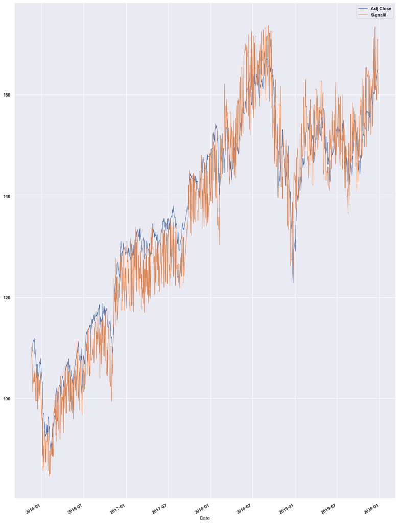

```python
df['Signal8'] =  8*df['Signal']
df[['Adj Close','Signal8']].plot(figsize = (15, 25),linewidth=1)
del df['Signal8']
```

```python
maxlag = 6
signalNames = ['Signal']
for lag in range(1,maxlag+1):
    signalNames.append('Signal.L%d'%lag)
    df['Signal.L%d'%lag] = df['Signal'].shift(lag)
```

In order to make the series first order stationary we consider the log-return. Given stationary times series we are able to identify correlations and causal relationships.

```python
def bivMove(start,end):
    return end - start
def univMove(x):
    return bivMove(x.shift(),x.shift())

def bivReturn(start,end,loga = True):
    if loga:
        return bivMove(np.log(start), np.log(end))
    else:
        return bivMove(start, end)/start
def univReturn(x,loga = True):
    return bivReturn(x.shift(),x,loga)


def bivVol(start,end):
    return np.square(bivReturn(start, end,False))
def univVol(x):
    return np.square(bivReturn(x.shift(), x,False))
```

Feature engineering. For this preliminary analysis we only focus on Adjusted Close daily log returns

```python
# biv = [['Open','Close'],['Low','High']]  # [start,end]
# univ = ['Adj Close','Open'] + signalNames
biv = []  # [start,end]
univ = ['Adj Close'] + signalNames
vol = False


returnNames = list()
volNames = list()
for u in univ:
    rName = u + 'LogReturn'
    returnNames.append(rName)
    df[rName] = univReturn(df[u])
    if vol:
        vName = u + 'Vol'
        volNames.append(vName)
        df[vName] = univVol(df[u])
for b in biv:
    base = ''.join(b)
    rName = base + 'LogReturn'
    returnNames.append(rName)
    df[rName] = bivReturn(df[b[0]],df[b[1]])
    if vol:
        vName = base + 'Vol'
        volNames.append(vName)
        df[vName] = bivVol(df[b[0]],df[b[1]])
```

```python
yname = 'Adj CloseLogReturn'
xname = 'SignalLogReturn'
```

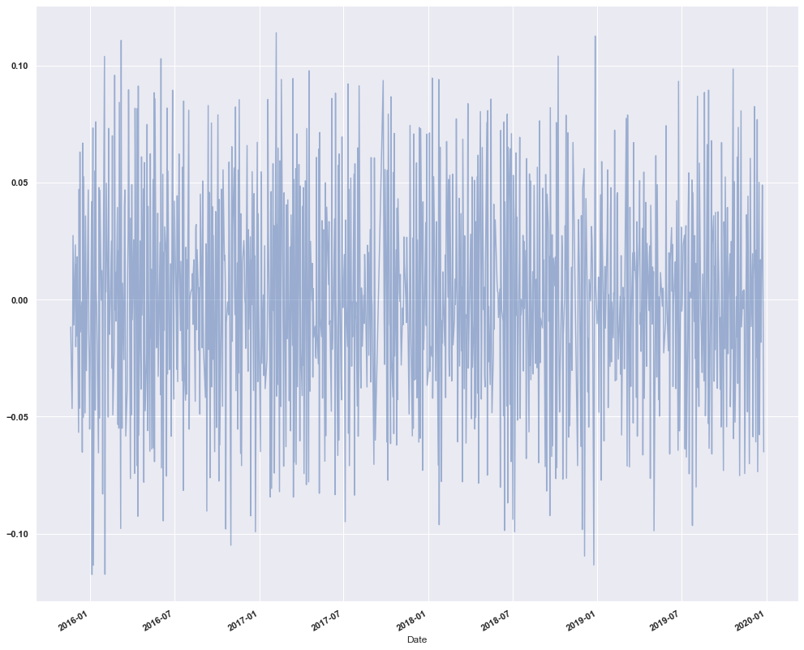

```python
df[xname].plot(figsize = (15, 15), alpha = 0.5)
```

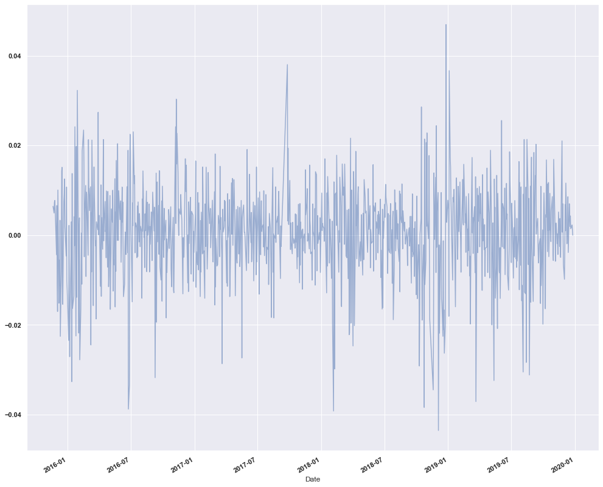

```python
df[yname].plot(figsize = (15, 15), alpha = 0.5)
```

#### 2.2 Data partition for training, testing, validation

We split the data set:

First, we perform the analysis on training set. Then we select stable conclusions with the test set. Lastly, we use the validation set to compute the selected metrics to the PM

```python
gap_period = ['2018-11-09','2018-11-19']
incorrect_period = ['2017-09-11','2017-09-22']
```

```python
df_model = df.copy()

train_end_date = '2017-09-10'
test_start_date = '2017-09-23'
test_end_date = '2018-11-09'
validation_start_date = '2018-11-19'

data_train = df_model[df_model.index <= train_end_date].copy()
data_test = df_model[(test_start_date<=df_model.index) & (df_model.index <= test_end_date)].copy()
data_validation = df_model[df_model.index >= validation_start_date].copy()

data = data_train.copy()
# data = data_test.copy()
# data = data_validation.copy()
```

```python
print('Train: %d trading days'%data_train.shape[0])
print('Test: %d trading days'%data_test.shape[0])
print('Validation: %d trading days'%data_validation.shape[0])
```

```
Train: 454 trading days
Test: 286 trading days
Validation: 277 trading days
```

#### 2.2 Correlation between the signal and the Adjusted Close price

In the training set(2015-2017) we find significant correlation between the Adjusted close price log return(Y) and the lag 3(X3) and 6(X6) Signal log returns.

Trading Y based on X3 gives good results.

Since the signal shows MA(1) autocorrelation scheme, we assume that X3 and X6 could contains independent information about Y and we simply sum them to build a signal feature to trade.

Observation from the end of the analysis: it would be more relevant to split the price return into 3 groups (high positive, low, high negative) and measure the signal classification power.

```python
from scipy.stats import kendalltau, pearsonr, spearmanr
def pearsonr_val(x,y):
    return pearsonr(x,y)[0]

def spearmanr_val(x,y):
    return spearmanr(x,y)[0]
def pearsonr_pval(x,y):
    return pearsonr(x,y)[1]

def spearmanr_pval(x,y):
    return spearmanr(x,y)[1]
```

Pearson correlation seems high for lag 2,3,5,6

```python
var_names = returnNames + volNames

corr = data[var_names].corr(pearsonr_val)

in_names = corr.index[[s[:6] == 'Signal' for s in corr.index]]
out_names = corr.columns[[s[:6] != 'Signal' for s in corr.columns]]

corr = corr.loc[in_names,out_names]

corr.style.background_gradient(cmap='coolwarm').set_precision(3)
```

|  | Adj CloseLogReturn |
| --- | --- |
| SignalLogReturn | -0.023 |
| Signal.L1LogReturn | -0.007 |
| Signal.L2LogReturn | 0.085 |
| Signal.L3LogReturn | 0.134 |
| Signal.L4LogReturn | 0.048 |
| Signal.L5LogReturn | -0.081 |
| Signal.L6LogReturn | 0.095 |

Spearman rank correlation seems high for lag 3,5,6

```python
corr = data[var_names].corr(spearmanr_val)
corr = corr.loc[[s[:6] == 'Signal' for s in corr.index], [s[:6] != 'Signal' for s in corr.columns]]
corr.style.background_gradient(cmap='coolwarm').set_precision(3)
```

|  | Adj CloseLogReturn |
| --- | --- |
| SignalLogReturn | -0.030 |
| Signal.L1LogReturn | 0.001 |
| Signal.L2LogReturn | 0.050 |
| Signal.L3LogReturn | 0.103 |
| Signal.L4LogReturn | 0.043 |
| Signal.L5LogReturn | -0.102 |
| Signal.L6LogReturn | 0.114 |

Peasron p-value rank correlation seems high for lag 3,6

Note: The p-value here is the probability that two independent samples mislead us and gave a absolute correlation greater or equal to observed correlation. Ex: On average, out of 100 randomly generated samples of independent (gaussian for Pearson) signals and returns series, only 5 samples would show a absolute correlation greater or equal than the one observed in our experiment

```python
#data1 = data[data.index<'2016-12-31']
#data1 = data[data.index>='2016-12-31']
data1 = data
# start = 100
# end = start+100
# data1 = data.iloc[start:end]
# data1 = data_train[data_train['SignalReturn']>-1]

corr = data1[var_names].corr(pearsonr_pval)
corr = corr.loc[[s[:6] == 'Signal' for s in corr.index], [s[:6] != 'Signal' for s in corr.columns]]
corr.style.apply(lambda col: ['background : green' if pval <= 0.05 else '' for pval in col],axis = 1).set_precision(2)
```

|  | Adj CloseLogReturn |
| --- | --- |
| SignalLogReturn | 0.62 |
| Signal.L1LogReturn | 0.88 |
| Signal.L2LogReturn | 0.07 |
| Signal.L3LogReturn | 0.00 |
| Signal.L4LogReturn | 0.31 |
| Signal.L5LogReturn | 0.09 |
| Signal.L6LogReturn | 0.05 |

```python
corr = data[var_names].corr(spearmanr_pval)
corr = corr.loc[[s[:6] == 'Signal' for s in corr.index], [s[:6] != 'Signal' for s in corr.columns]]

corr.style.apply(lambda col: ['background : green' if pval <= 0.05 else '' for pval in col],axis = 1).set_precision(2)
```

|  | Adj CloseLogReturn |
| --- | --- |
| SignalLogReturn | 0.53 |
| Signal.L1LogReturn | 0.98 |
| Signal.L2LogReturn | 0.29 |
| Signal.L3LogReturn | 0.03 |
| Signal.L4LogReturn | 0.36 |
| Signal.L5LogReturn | 0.03 |
| Signal.L6LogReturn | 0.02 |

```python
in_names = ['Signal.L3LogReturn','Signal.L6LogReturn']
var_names = list(out_names) + in_names
```

```python
def shortName(name):
    short_dict = {'Signal':'S','LogReturn':'','Adj ':'a','Open':'O','Close':'C','LowHigh':'HL'}
    for sub in short_dict.keys():
        name = name.replace(sub, short_dict[sub])
    return name
data_print = data[var_names].copy()
data_print.columns = data_print.columns.to_series().apply(shortName)
```

The scatter plot show a slight correlation. Note that Adjusted close return and Signal lag 3 return is composed of straight lines. It looks like if the signal values were simulated using logret(S(t-3)) = logret(aC(t)) + eps where eps = -0.1,-0.09,...,0.09,0.1 is sampled from a symmetric triangular distribution.

Notations for the scatter plot:

- aC is the adjusted close log return,
- S is the signal log return
- x.l2 is the variable x lagged by 2 days

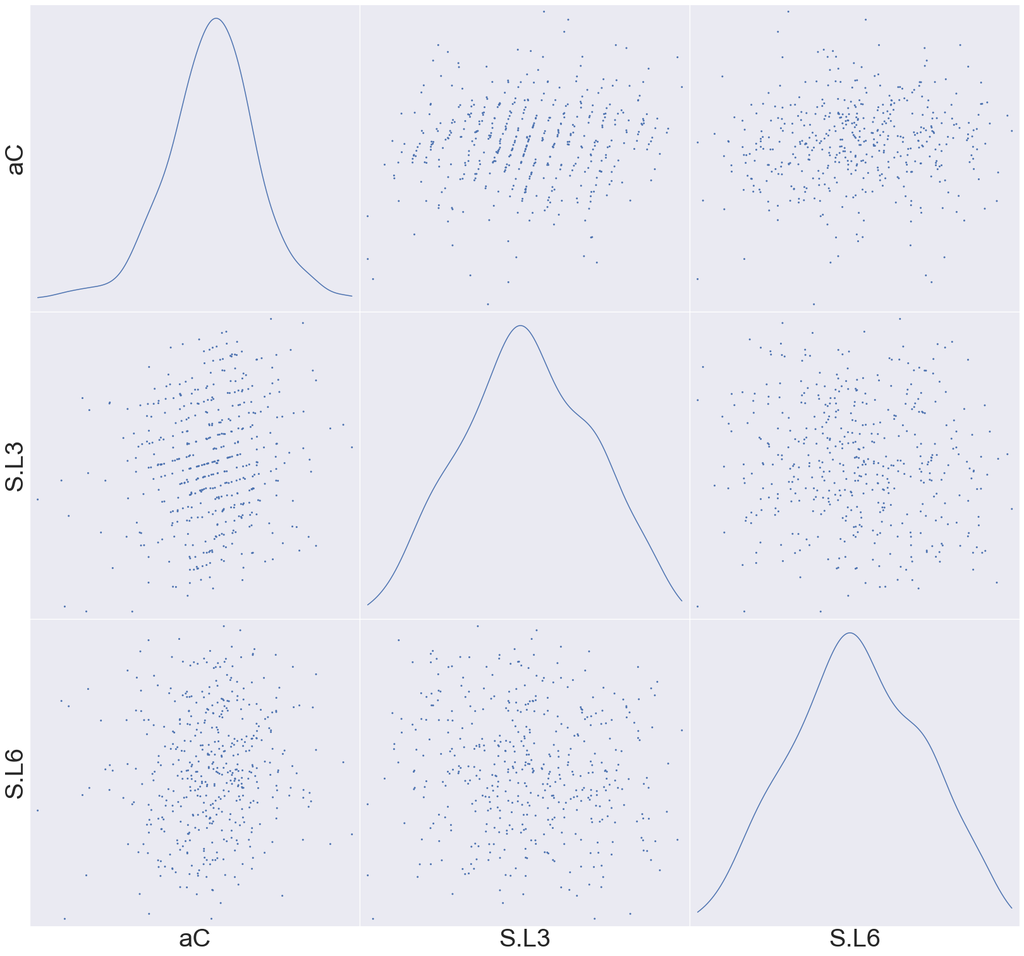

```python
from matplotlib.ticker import FormatStrFormatter


sm = pd.plotting.scatter_matrix(data_print, alpha=1, figsize=(25, 25), diagonal='kde')
#y ticklabels
[plt.setp(item.yaxis.get_majorticklabels(), 'size', 25) for item in sm.ravel()]
#x ticklabels
[plt.setp(item.xaxis.get_majorticklabels(), 'size', 25) for item in sm.ravel()]
#y labels
[plt.setp(item.yaxis.get_label(), 'size', 40) for item in sm.ravel()]
#x labels
[plt.setp(item.xaxis.get_label(), 'size', 40) for item in sm.ravel()];

#Hide all ticks
dummy = [s.set_xticks(()) for s in sm.reshape(-1)]
dummy = [s.set_yticks(()) for s in sm.reshape(-1)]
```

```python
lag = 3
yrname = 'Adj CloseLogReturn'
xrname = 'Signal.L%dLogReturn'%lag
```

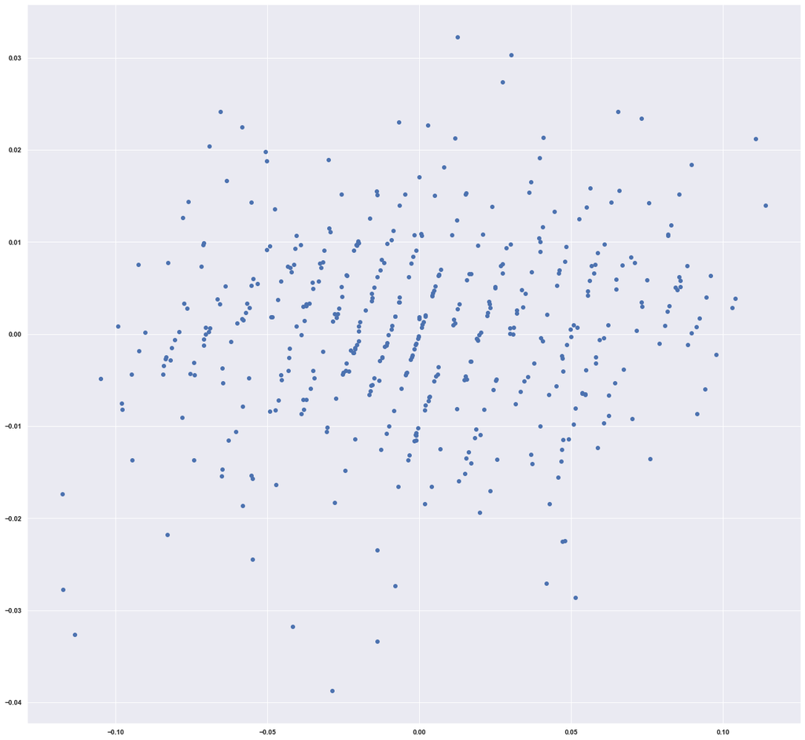

```python
plt.figure(figsize=(20,20))
plt.scatter(data[xrname], data[yrname])
```

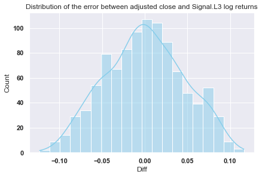

```python
df['Diff'] = df[yrname]-df[xrname]
title = 'Distribution of the error between adjusted close and Signal.L3 log returns'
fig = sns.histplot(data=df, x='Diff', color="skyblue", label="Positive signal", kde=True).set_title(title)
del df['Diff']
```

## 3 Trading Strategy

### 3.1 Trading on the training period before 2017

```python
def styleOutput(column1,column2):
    padding = 50
    for c1, c2 in zip(column1, column2):
        print("%s %s" % (c1.ljust(padding), c2))
# def avgHoldingPeriod(sign):
```

The price is more likely to increase from t-1 to t if the signal increases from t-4 to t-3. We can observe how the value of the lag 3 signal return slightly shift the distribution of the returns to the right leading to more positive returns.

Note also that the higher the signal is, the less trades we capture, the higher the returns

```
Signal.L3LogReturn>0 | Signal.L3LogReturn<0
```

|  | Adj CloseLogReturn | Adj CloseLogReturn |
| --- | --- | --- |
| count | 216.000000 | 231.000000 |
| mean | 0.001363 | -0.000544 |
| std | 0.010268 | 0.010135 |
| min | -0.028623 | -0.038748 |
| 25% | -0.005156 | -0.005011 |
| 50% | 0.001821 | -0.000077 |
| 75% | 0.007124 | 0.006092 |
| max | 0.032275 | 0.024163 |

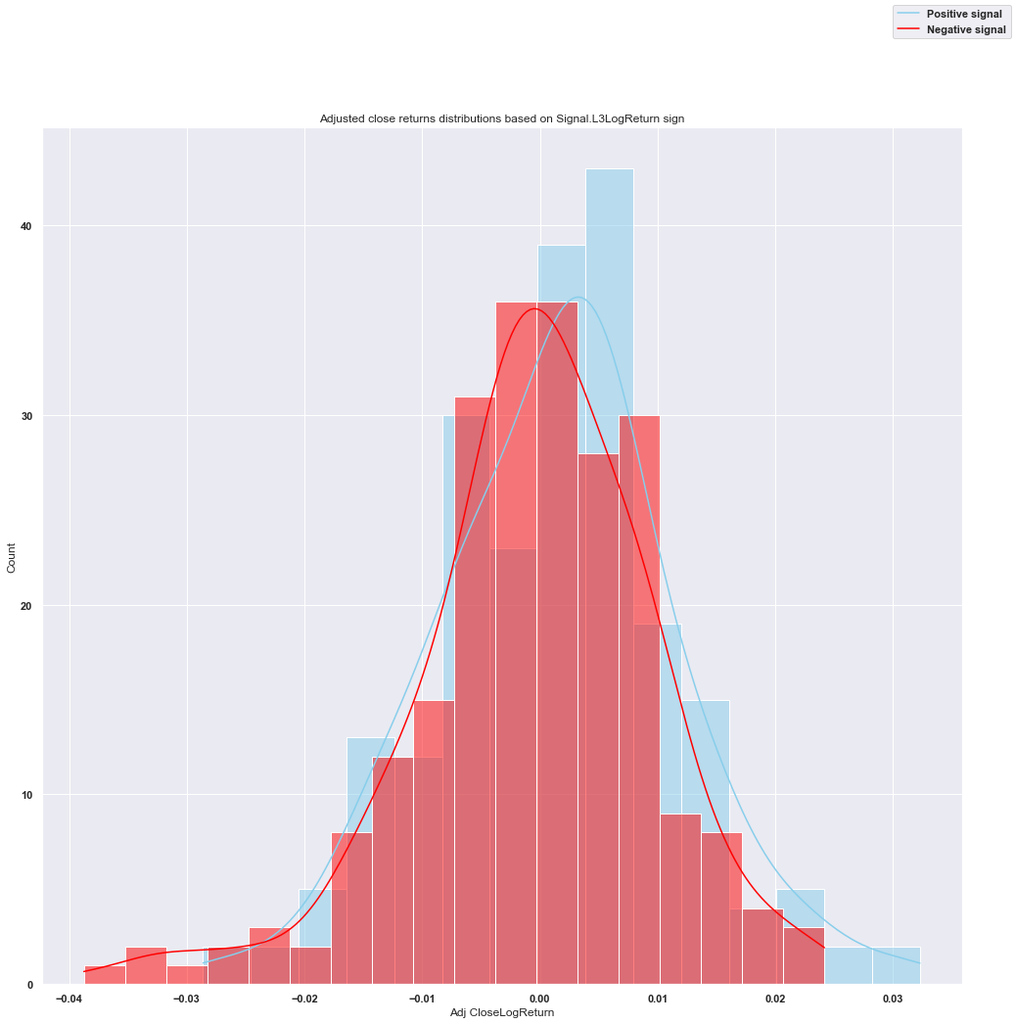

```python
pos = data.loc[data[xrname]>0]
neg = data.loc[data[xrname]<0]
fig = plt.figure(figsize=(15,15))
sns.histplot(data=pos, x=yrname, color="skyblue", label="Positive signal", kde=True)
sns.histplot(data=neg, x=yrname, color="red", label="Negative signal", kde=True).set_title('Adjusted close returns distributions based on %s sign'%xrname)
fig.legend(labels=['Positive signal','Negative signal'])

print(xrname+'>0'+' | ' +xrname+'<0')
pos[yrname].describe().to_frame().join(neg[yrname].describe(),lsuffix = '         ')
```

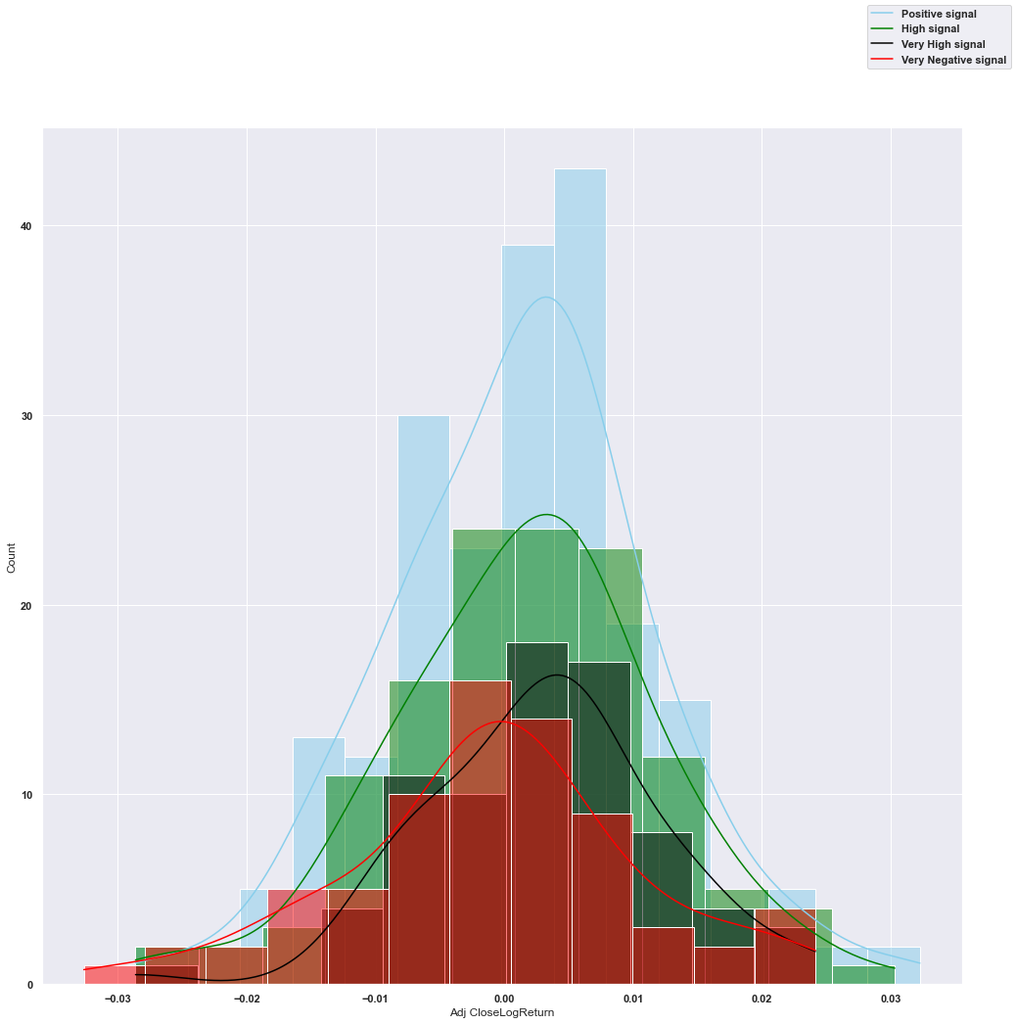

```python
pos0 = data.loc[data[xrname]>0]
pos3 = data.loc[data[xrname]>0.03]
pos5 = data.loc[data[xrname]>0.05]
pos_5 = data.loc[data[xrname]<-0.05]
fig = plt.figure(figsize=(15,15))
sns.histplot(data=pos, x=yrname, color="skyblue", label="Positive signal", kde=True)
sns.histplot(data=pos3, x=yrname, color="green", label="High signal", kde=True)
sns.histplot(data=pos5, x=yrname, color="black", label="Very High signal", kde=True)
sns.histplot(data=pos_5, x=yrname, color="red", label="Very Negative signal", kde=True)
fig.legend(labels=['Positive signal','High signal',"Very High signal","Very Negative signal"])
```

The 3 and 6 lags are uncorrelated so we build a stronger signal by summing them.

```python
# lags = [3,6]

# weights = [1,2,1]
def generateFeature(mdata,lags = [3,6],weights=None):
    if not weights:
        weights = np.ones(len(lags))
    snames = ['Signal.L%s'%lag for lag in lags if lag!=0]
    if 0 in lags:
        snames = 'Signal' + snames

    mdata['SignalFeature'] = np.array(mdata[snames]) @ np.array(weights)/ np.sum(weights)
    mdata['SignalFeatureLogReturn'] = univReturn(mdata['SignalFeature'])
    return mdata
data = generateFeature(data)
data_train = generateFeature(data_train)
```

```python
data[['SignalFeatureLogReturn',yrname]].corr()
```

|  | SignalFeatureLogReturn | Adj CloseLogReturn |
| --- | --- | --- |
| SignalFeatureLogReturn | 1.000000 | 0.169687 |
| Adj CloseLogReturn | 0.169687 | 1.000000 |

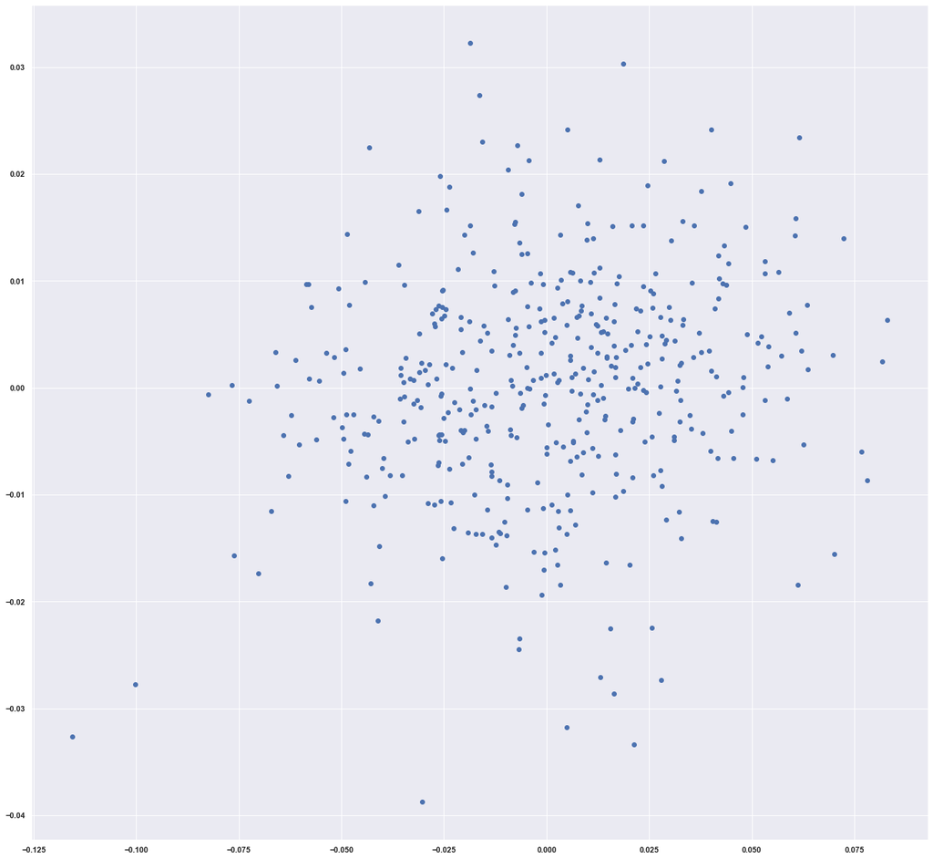

```python
plt.figure(figsize=(20,20))
plt.scatter(data['SignalFeatureLogReturn'], data[yrname])
```

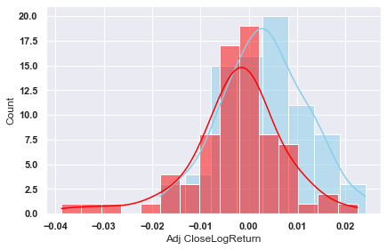

```python
input_name = 'SignalFeatureLogReturn'
pos = data.loc[data[input_name]>0.03]
neg = data.loc[data[input_name]<-0.03]
sns.histplot(data=pos, x=yrname, color="skyblue", label="Positive signal", kde=True)
sns.histplot(data=neg, x=yrname, color="red", label="Negative signal", kde=True)
```

```python
date_str = lambda x: x.strftime('%m/%d/%Y')

def pnlSimple(mdata,amount,returnName,signalName,thld_buy=-100,thld_sell=-100,plot_dist = False,trading_cost=1):

    c = trading_cost/10000 #trading cost is in bps. c is the trading cost per 1 dollar of order.
    output = list()
    hold = False
    if thld_buy==-100 and thld_sell==-100:
        hold = True

    if hold:
        output.append('Buy and Hold')
    else:
        output.append('Long the ETF when S>%d%%, Short when S<%d%%'%(100*thld_buy,100*thld_sell))
    sign = - 1*(mdata[signalName]<thld_sell) + 1*(mdata[signalName]>thld_buy)

    if(plot_dist):
        title = 'Returns distribution from %s to %s'%(date_str(mdata.index[0]),date_str(mdata.index[-1]))
        fig = plt.figure(figsize=(8,8))
        sns.histplot(data=mdata[sign==1], x=yrname, color="skyblue", label="Positive signal", kde=True)
        if(hold):
            fig.legend(labels=['Buy days'])
        else:
            sns.histplot(data=mdata[sign==-1], x=yrname, color="red", label="Negative signal", kde=True)
            sns.histplot(data=mdata[sign==0], x=yrname, color="grey", label="Mixed signal", kde=True).set_title(title)
            fig.legend(labels=['Buy days','Sell days','Flat Days'])

    r_hold = np.exp(mdata[returnName])-1
    r = r_hold * sign
    if hold:
        r[0]-=c
        r[r[r != 0].index[-1]] -=c
    else:
        r[r!=0] -= 2*c

    output.append('%d trading days from %s to %s' %(mdata.shape[0],date_str(mdata.index[0]),date_str(mdata.index[-1])))
    output += lreturnStats(r,amount)
    return output
```

We invest the same amount every day and clear the portfolio between each day

```python
def lreturnStats(r,amount):
    r_traded = r[r!=0]
    pnl = amount*np.sum(r)
    output = list()
    output.append('Daily acount size: %s'%locale.currency(amount))
    output.append('Total PnL: %s'%locale.currency(pnl))

    aer = 100*(np.prod(r+1)**(252/len(r)) - 1)
    output.append('Annualized Return: %d%%'%aer)
    std = 100*(r_traded.std() * np.sqrt(252))
    output.append('Annual Standard Deviation: %d%%'%std)
    sr = r_traded.mean()/r_traded.std() * np.sqrt(252)
    output.append('Sharpe Ratio: %.2f'%sr)
    ppd = 100*len(r_traded)/len(r)
    output.append('Proportion of days traded: %d%%'%ppd)
    ppm = 100*np.mean(r_traded>0)
    output.append('Proportion of positive days: %d%%'%ppm)

    s=(r+1).cumprod()
    dd = 100*np.ptp(s)/s.max()
    output.append('Maximum drawdown: %d%%'%dd)
    return output
```

#### 3.2 Define stable trading strategy (before 2017 VS 2018)

We keep the +/- 1\% thresholds to buy/sell the etf since they reach the best performance while being stable accross time

- Low signal threshold (0) allows us to trade every day while outperforming the buy and hold strategy in every period
- High signal threshold (1%) select provides an improved performance consistant across both period.
- Very high signal threshold (>1%) does not select enough trades and lead to very variable performance

```python
data_test = generateFeature(data_test)
data_validation = generateFeature(data_validation)
```

```python
rname = 'Adj CloseLogReturn'
sname = 'SignalFeatureLogReturn'
strat_train_hold = pnlSimple(data_train[[rname,sname]].dropna(axis = 0),100,rname,sname)
strat_test_hold = pnlSimple(data_test[[rname,sname]].dropna(axis = 0),100,rname,sname)
styleOutput(strat_train_hold,strat_test_hold)
```

```
Buy and Hold                                       Buy and Hold
447 trading days from 12/01/2015 to 09/08/2017     285 trading days from 09/26/2017 to 11/09/2018
Daily acount size: $100                            Daily acount size: $100
Total PnL: $21                                     Total PnL: $9
Annualized Return: 10%                             Annualized Return: 7%
Annual Standard Deviation: 16%                     Annual Standard Deviation: 14%
Sharpe Ratio: 0.71                                 Sharpe Ratio: 0.54
Proportion of days traded: 99%                     Proportion of days traded: 100%
Proportion of positive days: 54%                   Proportion of positive days: 56%
Maximum drawdown: 35%                              Maximum drawdown: 16%
```

```python
buy = sell = 0
strat_train = pnlSimple(data_train[[rname,sname]].dropna(axis = 0),100,rname,sname,buy,sell)
strat_test = pnlSimple(data_test[[rname,sname]].dropna(axis = 0),100,rname,sname,buy,sell)
styleOutput(strat_train,strat_test)
```

```
Long the ETF when S>0%, Short when S<0%            Long the ETF when S>0%, Short when S<0%
447 trading days from 12/01/2015 to 09/08/2017     285 trading days from 09/26/2017 to 11/09/2018
Daily acount size: $100                            Daily acount size: $100
Total PnL: $38                                     Total PnL: $22
Annualized Return: 22%                             Annualized Return: 19%
Annual Standard Deviation: 16%                     Annual Standard Deviation: 14%
Sharpe Ratio: 1.31                                 Sharpe Ratio: 1.31
Proportion of days traded: 99%                     Proportion of days traded: 100%
Proportion of positive days: 56%                   Proportion of positive days: 55%
Maximum drawdown: 30%                              Maximum drawdown: 22%
```

```python
buy = 0.01
sell = -buy
strat_train = pnlSimple(data_train[[rname,sname]].dropna(axis = 0),100,rname,sname,buy,sell)
strat_test = pnlSimple(data_test[[rname,sname]].dropna(axis = 0),100,rname,sname,buy,sell)
styleOutput(strat_train,strat_test)
```

```
Long the ETF when S>1%, Short when S<-1%           Long the ETF when S>1%, Short when S<-1%
447 trading days from 12/01/2015 to 09/08/2017     285 trading days from 09/26/2017 to 11/09/2018
Daily acount size: $100                            Daily acount size: $100
Total PnL: $45                                     Total PnL: $27
Annualized Return: 27%                             Annualized Return: 25%
Annual Standard Deviation: 15%                     Annual Standard Deviation: 14%
Sharpe Ratio: 2.16                                 Sharpe Ratio: 2.08
Proportion of days traded: 74%                     Proportion of days traded: 79%
Proportion of positive days: 59%                   Proportion of positive days: 57%
Maximum drawdown: 36%                              Maximum drawdown: 29%
```

```python
buy = 0.03
sell = -buy
strat_train = pnlSimple(data_train[[rname,sname]].dropna(axis = 0),100,rname,sname,buy,sell)
strat_test = pnlSimple(data_test[[rname,sname]].dropna(axis = 0),100,rname,sname,buy,sell)
styleOutput(strat_train,strat_test)
```

```
Long the ETF when S>3%, Short when S<-3%           Long the ETF when S>3%, Short when S<-3%
447 trading days from 12/01/2015 to 09/08/2017     285 trading days from 09/26/2017 to 11/09/2018
Daily acount size: $100                            Daily acount size: $100
Total PnL: $41                                     Total PnL: $4
Annualized Return: 25%                             Annualized Return: 3%
Annual Standard Deviation: 14%                     Annual Standard Deviation: 12%
Sharpe Ratio: 4.52                                 Sharpe Ratio: 0.77
Proportion of days traded: 34%                     Proportion of days traded: 38%
Proportion of positive days: 61%                   Proportion of positive days: 57%
Maximum drawdown: 33%                              Maximum drawdown: 7%
```

```python
buy = 0.05
sell = -buy
strat_train = pnlSimple(data_train[[rname,sname]].dropna(axis = 0),100,rname,sname,buy,sell)
strat_test = pnlSimple(data_test[[rname,sname]].dropna(axis = 0),100,rname,sname,buy,sell)
styleOutput(strat_train,strat_test)
```

```
Long the ETF when S>5%, Short when S<-5%           Long the ETF when S>5%, Short when S<-5%
447 trading days from 12/01/2015 to 09/08/2017     285 trading days from 09/26/2017 to 11/09/2018
Daily acount size: $100                            Daily acount size: $100
Total PnL: $16                                     Total PnL: ($3)
Annualized Return: 9%                              Annualized Return: -2%
Annual Standard Deviation: 15%                     Annual Standard Deviation: 10%
Sharpe Ratio: 4.79                                 Sharpe Ratio: -2.04
Proportion of days traded: 12%                     Proportion of days traded: 12%
Proportion of positive days: 61%                   Proportion of positive days: 56%
Maximum drawdown: 18%                              Maximum drawdown: 4%
```

We pick the 1% threshold as it appears to provide consistent results accross the period of times.

```
Long the ETF when S>1%, Short when S<-1%           Long the ETF when S>1%, Short when S<-1%
447 trading days from 12/01/2015 to 09/08/2017     285 trading days from 09/26/2017 to 11/09/2018
Daily acount size: $100                            Daily acount size: $100
Total PnL: $45                                     Total PnL: $27
Annualized Return: 27%                             Annualized Return: 25%
Annual Standard Deviation: 15%                     Annual Standard Deviation: 14%
Sharpe Ratio: 2.16                                 Sharpe Ratio: 2.08
Proportion of days traded: 74%                     Proportion of days traded: 79%
Proportion of positive days: 59%                   Proportion of positive days: 57%
Maximum drawdown: 36%                              Maximum drawdown: 29%
```

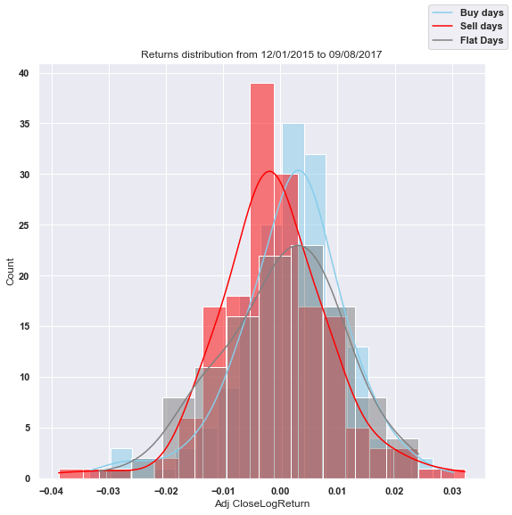

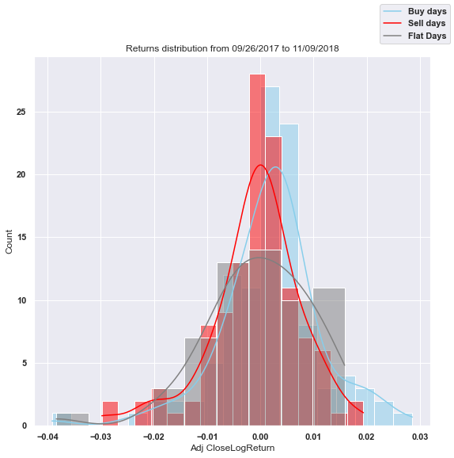

```python
buy = 0.01
sell = -buy
strat_train = pnlSimple(data_train[[rname,sname]].dropna(axis = 0),100,rname,sname,buy,sell,True)
strat_test = pnlSimple(data_test[[rname,sname]].dropna(axis = 0),100,rname,sname,buy,sell,True)
styleOutput(strat_train,strat_test)
```

#### 3.2 Test the trading strategy in 2019

The strategy performs well in the out-of-sample data that we have not looked at yet: 2019 trading days

```
Signal.L3LogReturn>0 | Signal.L3LogReturn<0
Buy and Hold                                       Long the ETF when S>1%, Short when S<-1%
276 trading days from 11/20/2018 to 12/26/2019     276 trading days from 11/20/2018 to 12/26/2019
Daily acount size: $100                            Daily acount size: $100
Total PnL: $15                                     Total PnL: $38
Annualized Return: 12%                             Annualized Return: 39%
Annual Standard Deviation: 17%                     Annual Standard Deviation: 17%
Sharpe Ratio: 0.75                                 Sharpe Ratio: 2.46
Proportion of days traded: 99%                     Proportion of days traded: 77%
Proportion of positive days: 54%                   Proportion of positive days: 59%
Maximum drawdown: 25%                              Maximum drawdown: 35%
```

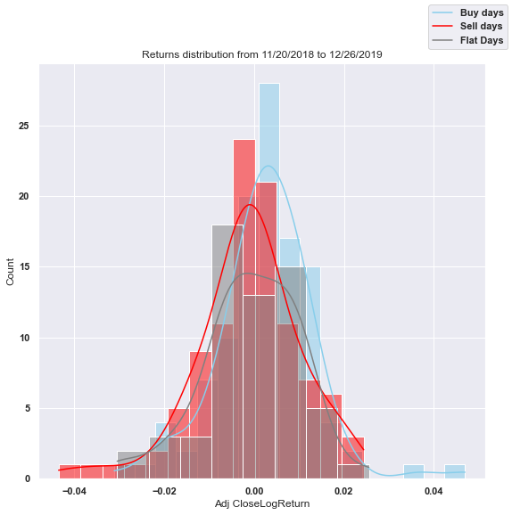

```python
buy = 0.01
sell = -buy
strat_validation_hold = pnlSimple(data_validation[[rname,sname]].dropna(axis = 0),100,rname,sname)
strat_validation = pnlSimple(data_validation[[rname,sname]].dropna(axis = 0),100,rname,sname,buy,sell,True)

print(xrname+'>0'+' | ' +xrname+'<0')
styleOutput(strat_validation_hold,strat_validation)
```